# Homework 4

Key

# Create a RStudio Project on your machine

- Name the Project “lab_4”
- Within the Project create a folder for *data* and *scripts*.
- Download the following three datasets into the project *data* folder.
  - *sesame13.sav*
  - *star.csv*
  - *ais.xlsx*
- Save a lab_4 .Rmd file in your *scripts* folder

# Part 1

Install and load the package `{Lahman}`, which will give you access to the *Teams* data.

```r
#install.packages("Lahman")
library(rio)
library(here)
library(tidyverse)
library(Lahman)
library(janitor)
```

#### 1. Produce a subset of the data (as a new object) that has the following characteristics:

- only one team (your choice)
- (try to you select a team that is currently still around, or it probably won’t be interesting; see a list of current at http://www.espn.com/mlb/teams).
- data from 1980 to present (or as current as the dataset allows)
- includes 5 columns: `name`, `yearID`, `W`, `L`, `R`, `RA`. These 5 variables correspond to the team name, the year, wins, losses, runs scored, and runs allowed).

```r
teams <- Teams %>%
  janitor::clean_names()

cubs <- teams %>%
    filter(name == "Chicago Cubs" & year_id >= 1980) %>% # Only one team (your choice) & data from 1980 to present
    select(name, year_id, w, l, r, ra) #Includes 5 columns: name, yearID, W, L, R, RA


# Create a new variable corresponding to the winning percentage for the team you chose over time
cubs <- cubs %>%
    mutate(w_pct = w / (w + l))
```

#### 2. Create a new variable corresponding to the winning percentage for the team you chose over time:

$$w_{pct} = \frac{wins}{wins + losses}$$
* Order by winning percentage: Least to greatest * Order by winning percentage: Greatest to least * Compute the `mean` and `standard deviation` of winning percentage

```r
# Order by winning percentage: Least to greatest
cubs %>%
  arrange(w_pct)
```

```
##            name year_id   w   l   r  ra     w_pct
## 1  Chicago Cubs    1981  38  65 370 483 0.3689320
## 2  Chicago Cubs    2012  61 101 613 759 0.3765432
## 3  Chicago Cubs    1980  64  98 614 728 0.3950617
## 4  Chicago Cubs    2000  65  97 764 904 0.4012346
## 5  Chicago Cubs    2006  66  96 716 834 0.4074074
## 6  Chicago Cubs    2013  66  96 602 689 0.4074074
## 7  Chicago Cubs    1999  67  95 747 920 0.4135802
## 8  Chicago Cubs    2002  67  95 706 759 0.4135802
## 9  Chicago Cubs    1997  68  94 687 759 0.4197531
## 10 Chicago Cubs    1994  49  64 500 549 0.4336283
## 11 Chicago Cubs    1986  70  90 680 781 0.4375000
## 12 Chicago Cubs    1983  71  91 701 719 0.4382716
## 13 Chicago Cubs    2011  71  91 654 756 0.4382716
## 14 Chicago Cubs    1982  73  89 676 709 0.4506173
```

[output cut: 27 more lines]

```r
# Order by winning percentage: greatest to least
cubs %>%
  arrange(desc(w_pct))
```

```
##            name year_id   w   l   r  ra     w_pct
## 1  Chicago Cubs    2016 103  58 808 556 0.6397516
## 2  Chicago Cubs    2008  97  64 855 671 0.6024845
## 3  Chicago Cubs    2015  97  65 689 608 0.5987654
## 4  Chicago Cubs    1984  96  65 762 658 0.5962733
## 5  Chicago Cubs    2018  95  68 761 645 0.5828221
## 6  Chicago Cubs    1989  93  69 702 623 0.5740741
## 7  Chicago Cubs    2017  92  70 822 695 0.5679012
## 8  Chicago Cubs    2020  34  26 265 240 0.5666667
## 9  Chicago Cubs    1998  90  73 831 792 0.5521472
## 10 Chicago Cubs    2004  89  73 789 665 0.5493827
## 11 Chicago Cubs    2001  88  74 777 701 0.5432099
## 12 Chicago Cubs    2003  88  74 724 683 0.5432099
## 13 Chicago Cubs    2007  85  77 752 690 0.5246914
## 14 Chicago Cubs    1993  84  78 738 739 0.5185185
```

[output cut: 27 more lines]

```r
# Compute the mean and standard deviation of winning percentage
cubs %>%
  summarize(mean_winning_pct = mean(w_pct),
            sd_winning_pct = sd(w_pct))
```

```
##   mean_winning_pct sd_winning_pct
## 1        0.4887002     0.06961756
```

#### 3. With the full *Teams* data:

- Compute the `mean` and `standard deviation` of winning percentage for each team
- Order by winning percentage, greatest to least

```r
teams %>%
  mutate(w_pct = w / (w + l)) %>% # FIRST - compute the winning percentage
  group_by(name) %>%
  summarize(n = n(),
            mean_winning_pct = mean(w_pct, na.rm = TRUE), # compute the average winning percentage for each team
            sd_winning_pct = sd(w_pct, na.rm = TRUE)) %>% # compute the standard deviation of winning percentage for each team
  arrange(desc(mean_winning_pct)) # Order by highest winning percentage
```

```
## # A tibble: 139 x 4
##    name                         n mean_winning_pct sd_winning_pct
##    <chr>                    <int>            <dbl>          <dbl>
##  1 Boston Red Stockings         5            0.773         0.0911
##  2 Cincinnati Outlaw Reds       1            0.657        NA
##  3 Boston Reds                  3            0.616         0.0790
##  4 Providence Grays             8            0.609         0.0855
##  5 Chicago White Stockings     17            0.609         0.117
##  6 Cincinnati Red Stockings     8            0.589         0.0640
##  7 Boston Red Caps              7            0.579         0.0976
##  8 New York Yankees           108            0.577         0.0690
##  9 Brooklyn Ward's Wonders      1            0.576        NA
## 10 Philadelphia Whites          3            0.574         0.0934
## # ... with 129 more rows
```

#### 4. Use the full data to reproduce the plot below

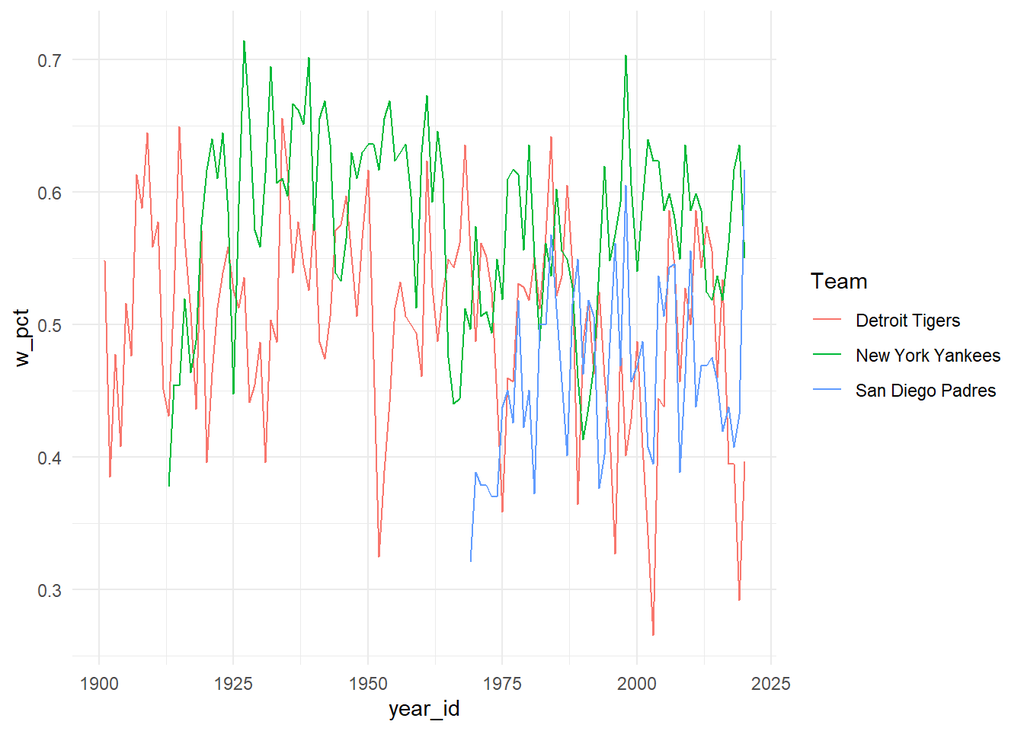

```r
# Please put the code for the plot in this chunk.
teams %>%
  as_tibble() %>%
  mutate(w_pct = w / (w + l)) %>%
  filter(name == "New York Yankees" |
         name == "Detroit Tigers" |
         name == "San Diego Padres") %>%
  ggplot(aes(year_id, w_pct)) +
  geom_line(aes(color = name)) +
  theme_minimal() +
  labs(
    color = "Team"
  )
```

# Part 2

#### 1. Read in the following three datasets, using `{here}` and the package of your choice (`{rio}`, `{readr}`, `{haven}`, `{readxl}`)

- *sesame13.sav*
- *star.csv*
- *ais.xlsx*

**Hint**: For the *ais.xlsx* data, look at the `skip` argument within the [`{readxl}`](https://readxl.tidyverse.org/reference/read_excel.html) help documentation.

```r
sesame <- import(here("data", "sesame13.sav"))
star <- import(here("data", "star.csv"))
ais <- import(here("data", "ais.xlsx"), skip = 15)
```

#### 2. Using the *ais* data, compute the average red blood cell count and average `bmi` by sport. Output these data as SPSS and EXCEL files.

```r
smry <- ais %>%
  group_by(sport) %>%
  summarize(mean_rcc = mean(rcc),
            mean_bmi = mean(bmi))

export(smry, "summary_measures.sav")
export(smry, "summary_measures.xlsx")
```

#### 3. Use the *sesame* data to answer the following question: Was the average female age higher in schools or at home?

```r
sesame %>%
  characterize() %>%
  filter(sex == "Female") %>%
  group_by(setting) %>%
  summarize(mean_age = mean(age))
```

```
## # A tibble: 2 x 2
##   setting mean_age
##   <chr>      <dbl>
## 1 Home        49.4
## 2 School      53.1
```

```r
# Answer: School
```

#### 4. First, how many rows and columns are in the *star* data? Next, remove outliers using a really poor method, just for practice, by eliminating students whose math (`tmathss`) scores were more than three standard deviations *above **or** below* the corresponding mean. How many rows are in the data now?

```r
dim(star) # 5748 rows, 12 columns
```

```
## [1] 5748   12
```

```r
star %>%
  filter(tmathss <= mean(tmathss) + 3*sd(tmathss) &
         tmathss >= mean(tmathss) - 3*sd(tmathss)) %>%
  nrow()
```

```
## [1] 5743
```

```r
# Answer: 5743
```

#### 5. Use the *star* data to compute standardized math and reading scores; name these variables *tmathss* and *treadss*. To create standardized scores, for each variable (math and reading), subtract the mean from each observation and divide by the standard deviation: $x_s = \frac{x_i - \bar{X}}{sd(X)}$.

- Check that your computations were correct by computing the mean and standard deviation of each variable (they should be 0 and 1, respectively).
- Compute the mean of the standardized variable for all `sex`/`frl` combinations. (I’m asking you to extend what you know here. We haven’t talked explicitly about how to do this yet, but you have seen examples).
- What do you make of these findings? Do you see an effect by `sex`? An `frl` effect (`frl` stands for free/reduced lunch, and is a rough proxy for household income)? Is there evidence of an interaction (i.e., that the effect of `frl` is greater for boys versus girls)?

```r
star <- star %>%
  mutate(stand_math = (tmathss - mean(tmathss)) / sd(tmathss),
         stand_rdg  = (treadss - mean(treadss)) / sd(treadss))

star %>%
  summarize(stand_math_mean = mean(stand_math),
            stand_math_sd   = sd(stand_math),
            stand_rdg_mean = mean(stand_rdg),
            stand_rdg_sd   = sd(stand_rdg))
```

```
##   stand_math_mean stand_math_sd stand_rdg_mean stand_rdg_sd
## 1     2.29625e-16             1  -6.278158e-16            1
```

```r
star %>%
  group_by(sex, frl) %>%
  summarize(stand_math_mean = mean(stand_math),
            stand_math_sd   = sd(stand_math),
            stand_rdg_mean = mean(stand_rdg),
            stand_rdg_sd   = sd(stand_rdg))
```

```
## # A tibble: 4 x 6
## # Groups:   sex [2]
##   sex   frl   stand_math_mean stand_math_sd stand_rdg_mean stand_rdg_sd
##   <chr> <chr>           <dbl>         <dbl>          <dbl>        <dbl>
## 1 boy   no              0.151         0.970          0.148        1.02
## 2 boy   yes            -0.330         0.965         -0.358        0.838
## 3 girl  no              0.326         0.962          0.371        1.09
## 4 girl  yes            -0.170         0.969         -0.187        0.863
```

#### Please submit you .Rmd file, as well as the rendered .html file.